# Comparing Stan model to edgeR

# Discussion

The Stan model with marginalization seems to work ok with easy simulated data sets, and outperforms the JAGS model. This reassures me that there is not a fundamental error in this approach or the implementation. As a next step, I compare my Stan model to edgeR.

Two thoughts after looking at the experiments below:

- My models are better than edgeR at estimating logFC
- When it’s harder to distinguish null and non-nulls, my models are liberal and edgeR is conservative with FDR control

This increases my curiousity about a ROPE-like approach like we discussed briefly last month, that classifies genes using a threshold for estimated FCs instead of a hypothesis test.

Next steps I am considering:

- Compare the Stan models to edgeR using simulations based more closely on real data
- Try to figure out why the Stan models are liberal with FDR control

# Experiments

## Model 1: clearly separated

I started with the last simulation setting I had used to compare Stan and JAGS, which included:

- Two treatment conditions
  - Log-scale treatment effects simulated from a two-component mixture of normals centered at $\pm 2$
  - 50% of genes are true nulls
- Paired samples with shared random effects
- Sample normalization factors,

but because the non-nulls were so clearly separated from null genes, this setting was quite easy for both methods.

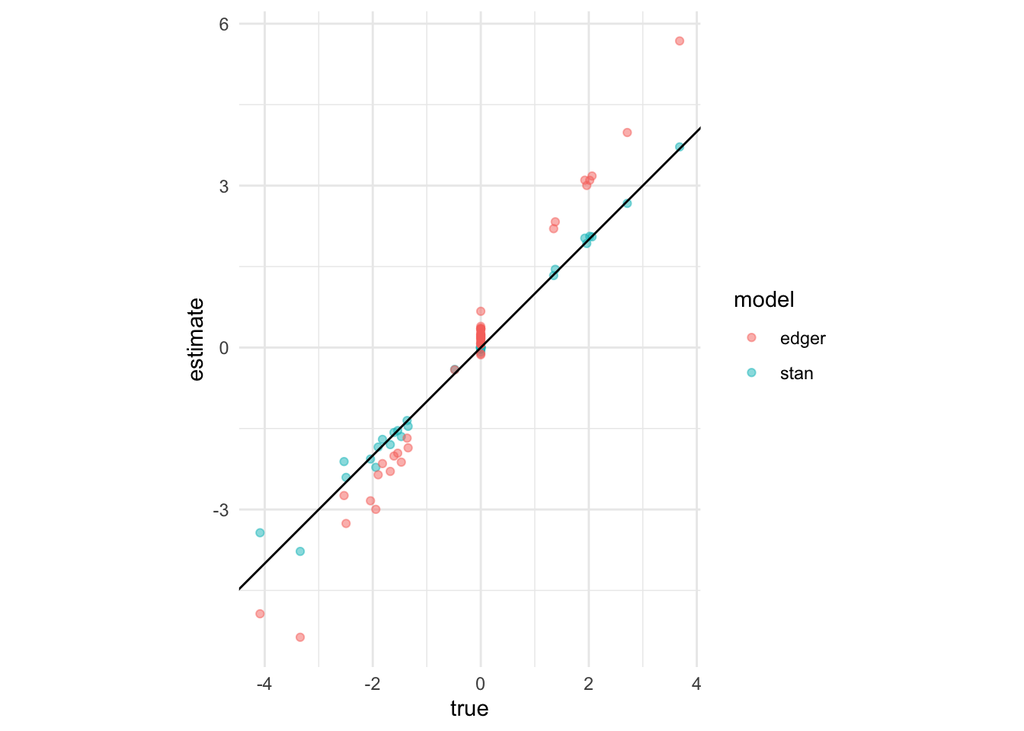

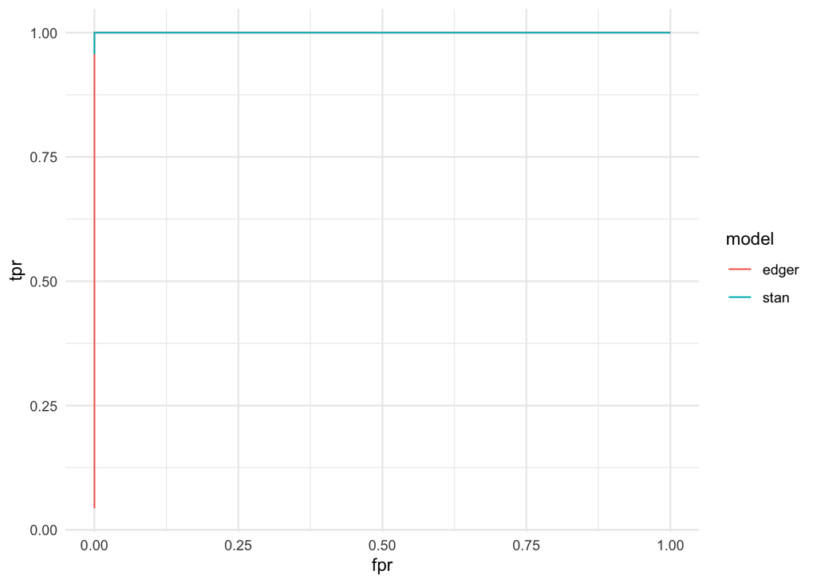

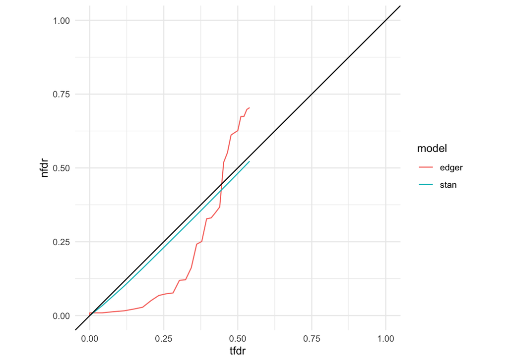

## Model 2: ambiguous

- Like Model 1, except:
  - Two-component mixture of normals for simulated treatment effects is centered at $\pm 0.7$ instead of $\pm 2$
  - 80% of genes are true nulls

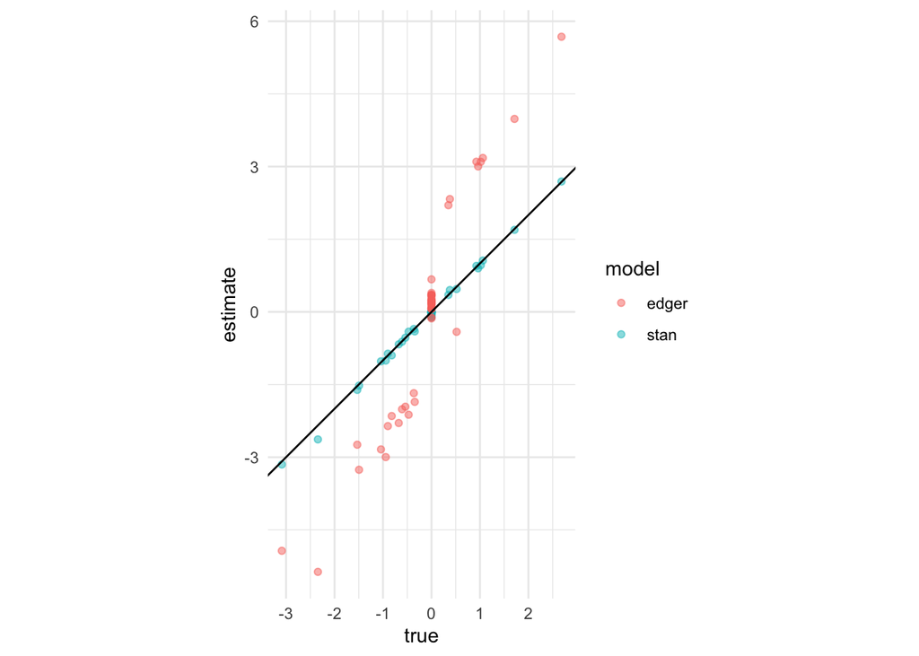

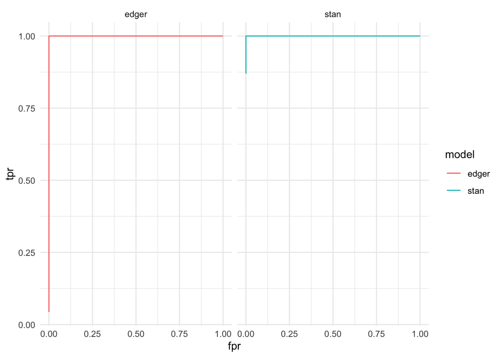

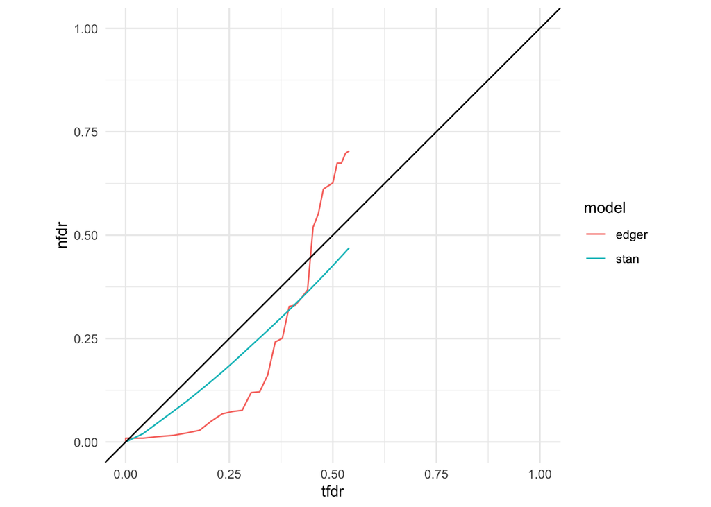

## Model 3: treatment effects centered at 0

- Like Model 2, except treatment effects are simulated from a standard normal

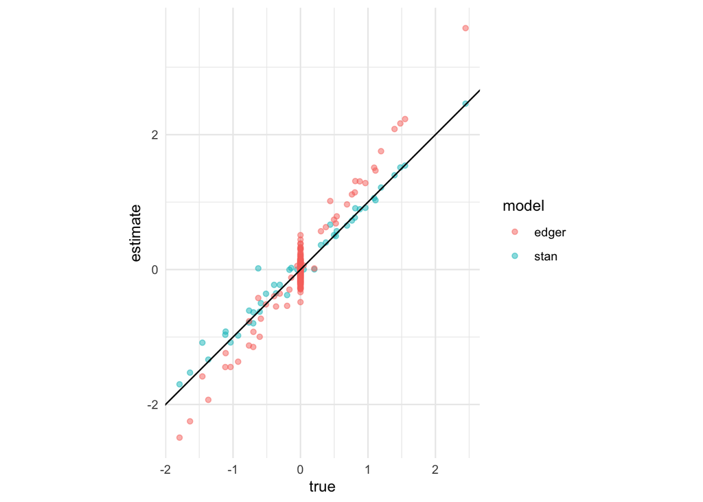

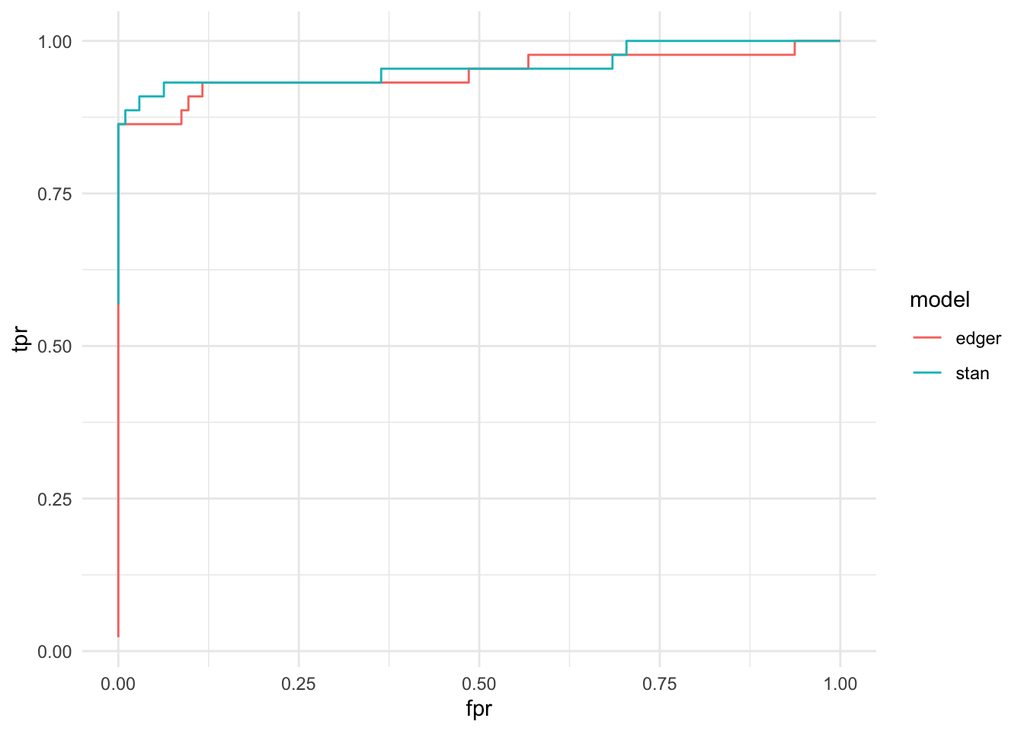

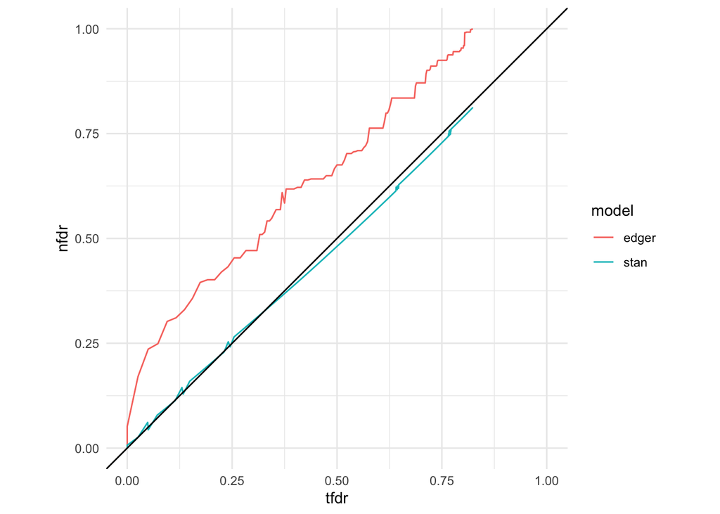

## Model 4: treatment effects with minimum FC cutoff

- Like Models 2 & 3, except treatment effects are simulated as $\pm \text{ln}(1.5 + \text{exp}(1))$
  - In other words, take $G$ draws from $\text{exp(1)}$, add 1.5, take the log, and then randomly flip 50% to negative
  - I tried this because it’s an approach that appears in a few papers

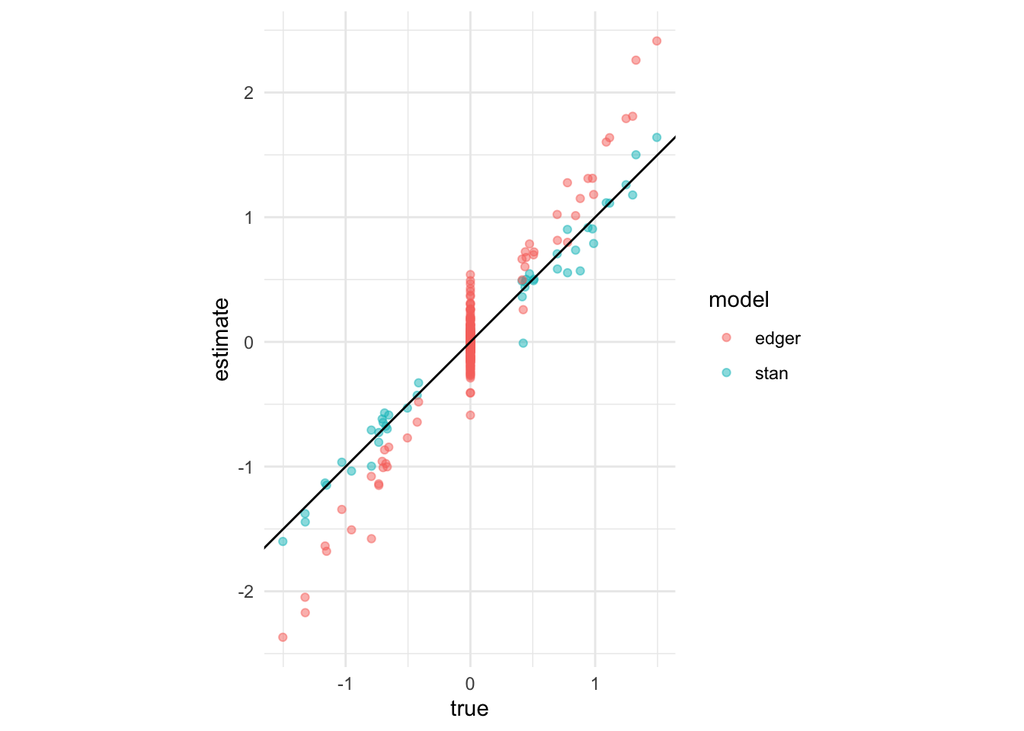

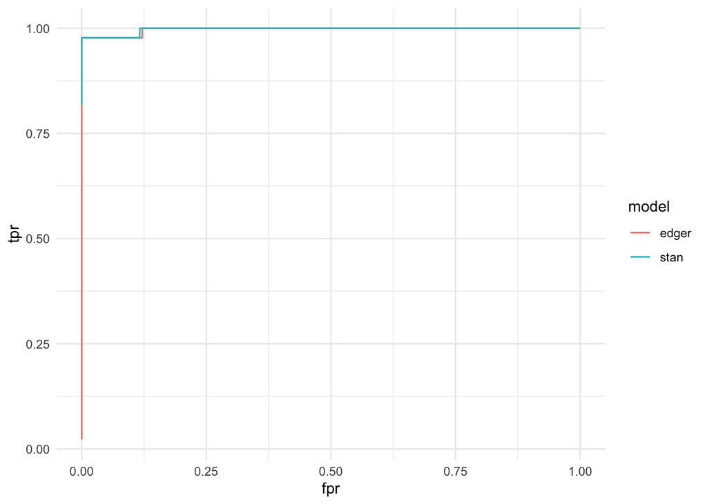

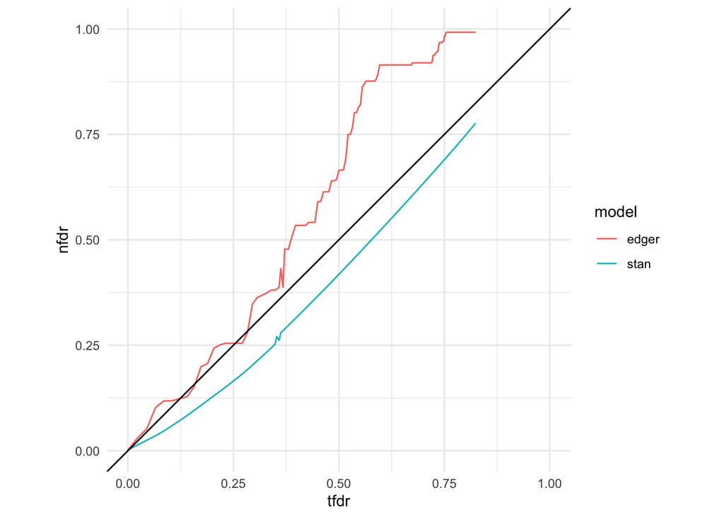

## Model 5: negative binomial counts and minimum abs. val. cutoff

- Like Model 4, except:
  - Counts are simulated from negative binomial
  - Gene-specific BCVs are sampled uniformly from $[0.01, 0.4]$
    - This range is based on ‘typical’ values mentioned by edgeR authors

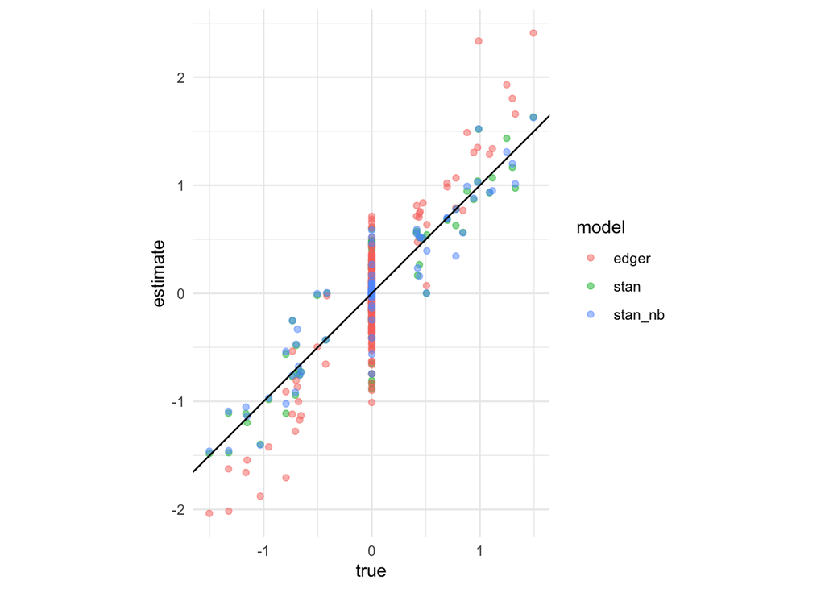

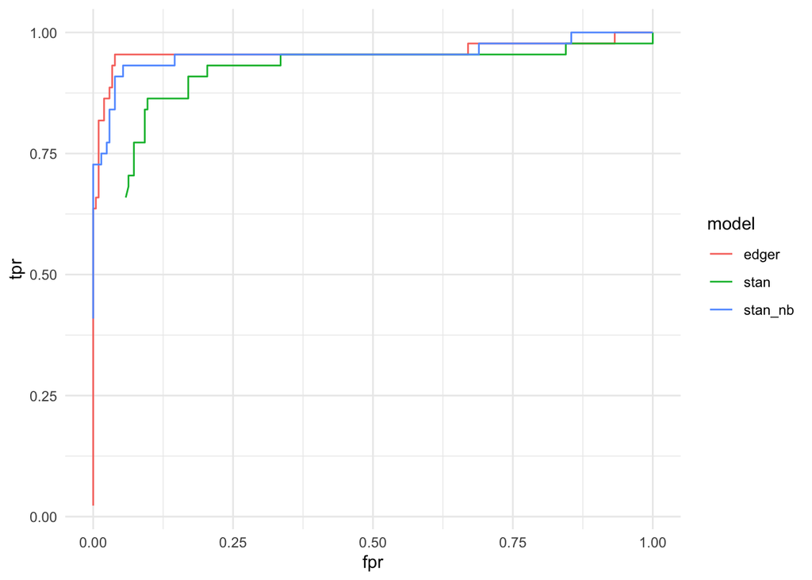

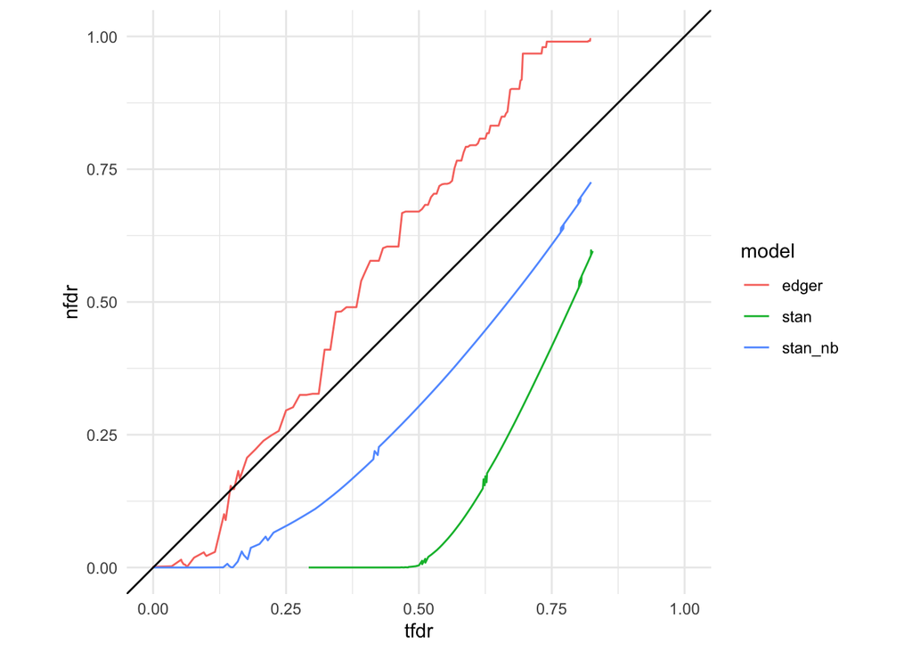